# Time dependent Cox: sensitivity analysis in patients who survived over 180 days

**Age of entry**

```r
cox1 <- coxph(Surv(time1, time2, event_death) ~ age_entry, data = all_df)

summary(cox1)
```

```
## Call:
## coxph(formula = Surv(time1, time2, event_death) ~ age_entry,
##     data = all_df)
##
##   n= 47952, number of events= 3062
##
##               coef exp(coef) se(coef)     z Pr(>|z|)
## age_entry 0.068387  1.070779 0.002679 25.52   <2e-16 ***
## ---
## Signif. codes:  0 '***' 0.001 '**' 0.01 '*' 0.05 '.' 0.1 ' ' 1
##
##           exp(coef) exp(-coef) lower .95 upper .95
## age_entry     1.071     0.9339     1.065     1.076
##
## Concordance= 0.638  (se = 0.006 )
## Likelihood ratio test= 710.9  on 1 df,   p=<2e-16
## Wald test            = 651.5  on 1 df,   p=<2e-16
## Score (logrank) test = 660  on 1 df,   p=<2e-16
```

```r
cox.zph(cox1)
```

```
##           chisq df     p
## age_entry  4.61  1 0.032
## GLOBAL     4.61  1 0.032
```

```
## [1] "Schoenfeld's test results for age of entry"
## [1] "Beta(t) for age of entry"
```

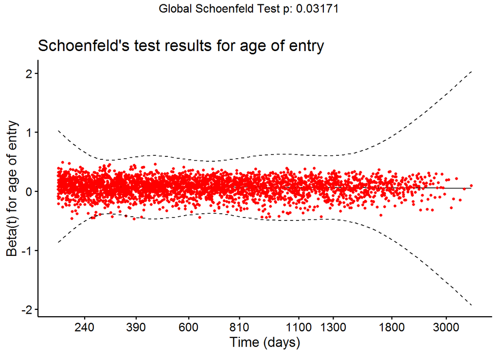

```r
res1 <- cox.zph(cox1)

plot_schoenfeld(res1, "age of entry")
```

```r
anova(cox1)
```

```
## Analysis of Deviance Table
##  Cox model: response is Surv(time1, time2, event_death)
## Terms added sequentially (first to last)
##
##           loglik  Chisq Df Pr(>|Chi|)
## NULL      -23650
## age_entry -23295 710.91  1  < 2.2e-16 ***
## ---
## Signif. codes:  0 '***' 0.001 '**' 0.01 '*' 0.05 '.' 0.1 ' ' 1
```

**Age at observation**

```r
cox2 <- coxph(Surv(time1, time2, event_death) ~ age_obsv, data = all_df)

summary(cox2)
```

```
## Call:
## coxph(formula = Surv(time1, time2, event_death) ~ age_obsv, data = all_df)
##
##   n= 47952, number of events= 3062
##
##              coef exp(coef) se(coef)     z Pr(>|z|)
## age_obsv 0.076572  1.079580 0.002702 28.34   <2e-16 ***
## ---
## Signif. codes:  0 '***' 0.001 '**' 0.01 '*' 0.05 '.' 0.1 ' ' 1
##
##          exp(coef) exp(-coef) lower .95 upper .95
## age_obsv      1.08     0.9263     1.074     1.085
##
## Concordance= 0.648  (se = 0.006 )
## Likelihood ratio test= 889.8  on 1 df,   p=<2e-16
## Wald test            = 803.1  on 1 df,   p=<2e-16
## Score (logrank) test = 813.8  on 1 df,   p=<2e-16
```

```r
cox.zph(cox2)
```

```
##          chisq df   p
## age_obsv 0.149  1 0.7
## GLOBAL   0.149  1 0.7
```

```
## [1] "Schoenfeld's test results for age at observation"
## [1] "Beta(t) for age at observation"
```

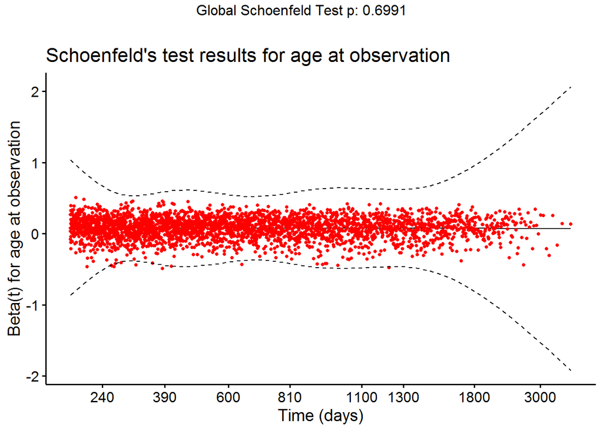

```r
res2 <- cox.zph(cox2)

plot_schoenfeld(res2, "age at observation")
```

```r
anova(cox2)
```

```
## Analysis of Deviance Table
##  Cox model: response is Surv(time1, time2, event_death)
## Terms added sequentially (first to last)
##
##          loglik  Chisq Df Pr(>|Chi|)
## NULL     -23650
## age_obsv -23205 889.79  1  < 2.2e-16 ***
## ---
## Signif. codes:  0 '***' 0.001 '**' 0.01 '*' 0.05 '.' 0.1 ' ' 1
```

**Age of diagnosis**

```r
cox3 <- coxph(Surv(time1, time2, event_death) ~ age_diag, data = all_df)

summary(cox3)
```

```
## Call:
## coxph(formula = Surv(time1, time2, event_death) ~ age_diag, data = all_df)
##
##   n= 47952, number of events= 3062
##
##              coef exp(coef) se(coef)    z Pr(>|z|)
## age_diag 0.062591  1.064591 0.002586 24.2   <2e-16 ***
## ---
## Signif. codes:  0 '***' 0.001 '**' 0.01 '*' 0.05 '.' 0.1 ' ' 1
##
##          exp(coef) exp(-coef) lower .95 upper .95
## age_diag     1.065     0.9393     1.059      1.07
##
## Concordance= 0.632  (se = 0.006 )
## Likelihood ratio test= 632.8  on 1 df,   p=<2e-16
## Wald test            = 585.8  on 1 df,   p=<2e-16
## Score (logrank) test = 592.5  on 1 df,   p=<2e-16
```

```r
cox.zph(cox3)
```

```
##          chisq df    p
## age_diag  6.57  1 0.01
## GLOBAL    6.57  1 0.01
```

```
## [1] "Schoenfeld's test results for age of diagnosis"
## [1] "Beta(t) for age of diagnosis"
```

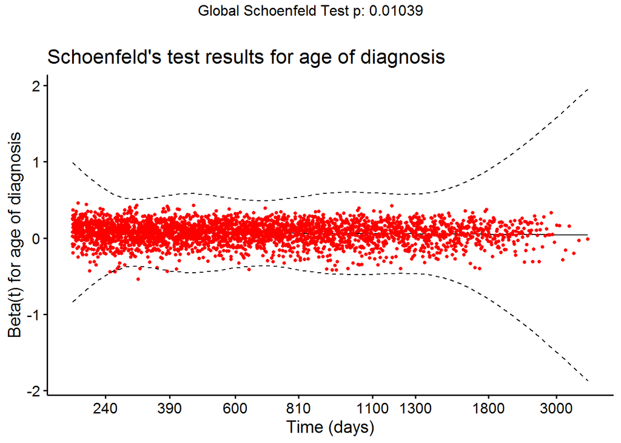

```r
res3 <- cox.zph(cox3)

plot_schoenfeld(res3, "age of diagnosis")
```

```r
anova(cox3)
```

```
## Analysis of Deviance Table
##  Cox model: response is Surv(time1, time2, event_death)
## Terms added sequentially (first to last)
##
##          loglik  Chisq Df Pr(>|Chi|)
## NULL     -23650
## age_diag -23334 632.78  1  < 2.2e-16 ***
## ---
## Signif. codes:  0 '***' 0.001 '**' 0.01 '*' 0.05 '.' 0.1 ' ' 1
```

**Dementia medication exposure**

```r
table(all_df$med_exposure)
```

```
##
##   exposed unexposed
##     37062     10890
```

```r
cox4 <- coxph(Surv(time1, time2, event_death) ~ med_exposure, data = all_df)

summary(cox4)
```

```
## Call:
## coxph(formula = Surv(time1, time2, event_death) ~ med_exposure,
##     data = all_df)
##
##   n= 47952, number of events= 3062
##
##                           coef exp(coef) se(coef)      z Pr(>|z|)
## med_exposureunexposed -0.26078   0.77045  0.04074 -6.402 1.53e-10 ***
## ---
## Signif. codes:  0 '***' 0.001 '**' 0.01 '*' 0.05 '.' 0.1 ' ' 1
##
##                       exp(coef) exp(-coef) lower .95 upper .95
## med_exposureunexposed    0.7704      1.298    0.7113    0.8345
##
## Concordance= 0.515  (se = 0.005 )
## Likelihood ratio test= 42.54  on 1 df,   p=7e-11
## Wald test            = 40.98  on 1 df,   p=2e-10
## Score (logrank) test = 41.21  on 1 df,   p=1e-10
```

```r
cox.zph(cox4)
```

```
##              chisq df       p
## med_exposure    30  1 4.4e-08
## GLOBAL          30  1 4.4e-08
```

```
## [1] "Schoenfeld's test results for dementia medication exposure"
## [1] "Beta(t) for dementia medication exposure"
```

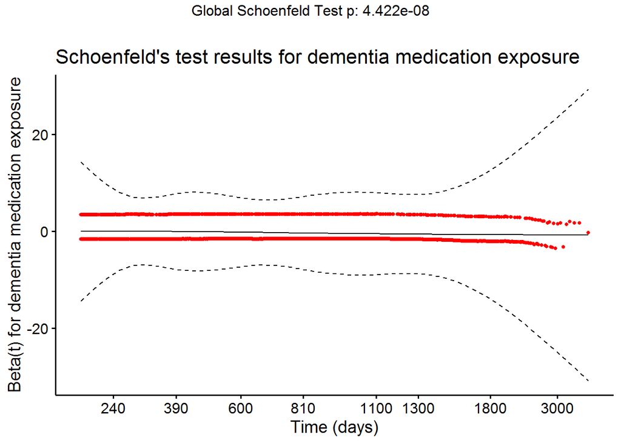

```r
res4 <- cox.zph(cox4)

plot_schoenfeld(res4, "dementia medication exposure")
```

```
## [1] "Survival probablity in OxNHS dementia patients: Survivors 180+ days"
## [1] "Adjusted for dementia medication exposure (time-dependent analysis)"
```

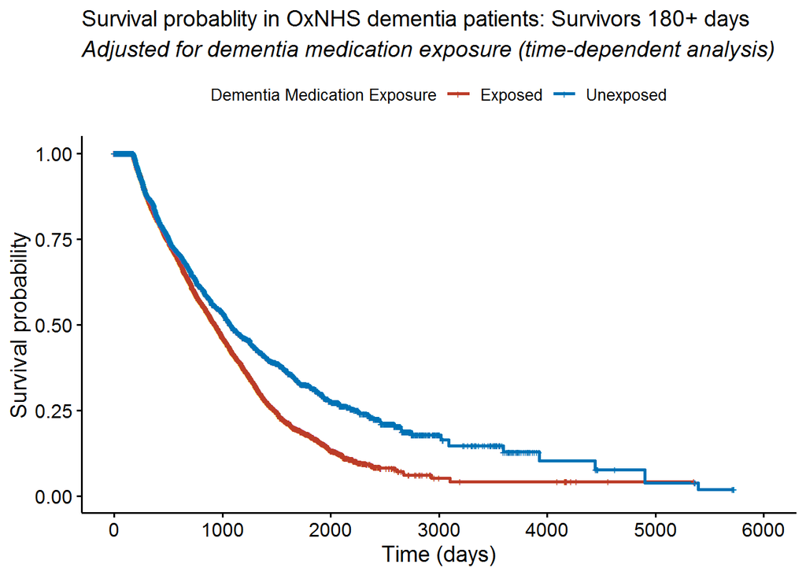

```r
fit4 <- survfit(Surv(time1, time2, event_death) ~ med_exposure, data = all_df)

plot_surv(fit4, "dementia medication exposure", c("Exposed", "Unexposed"))
```

```r
anova(cox4)
```

```
## Analysis of Deviance Table
##  Cox model: response is Surv(time1, time2, event_death)
## Terms added sequentially (first to last)
##
##              loglik  Chisq Df Pr(>|Chi|)
## NULL         -23650
## med_exposure -23629 42.538  1  6.931e-11 ***
## ---
## Signif. codes:  0 '***' 0.001 '**' 0.01 '*' 0.05 '.' 0.1 ' ' 1
```

**Initial dementia diagnosis**

```r
freq_per_info(all_df$cause_diagper)
```

```
## var :
##             Frequency Percent Cum. percent
## Unspecified     27037    56.4         56.4
## AD              16425    34.3         90.6
## VaD              2260     4.7         95.3
## DLB              1309     2.7         98.1
## MixedADVaD        462     1.0         99.0
## FTD               365     0.8         99.8
## PPD                94     0.2        100.0
##   Total         47952   100.0        100.0
```

```r
cox5 <- coxph(Surv(time1, time2, event_death) ~ cause_diagper, data = all_df)

summary(cox5)
```

```
## Call:
## coxph(formula = Surv(time1, time2, event_death) ~ cause_diagper,
##     data = all_df)
##
##   n= 47952, number of events= 3062
##
##                              coef exp(coef) se(coef)      z Pr(>|z|)
## cause_diagperDLB          0.35592   1.42749  0.11811  3.013  0.00258 **
## cause_diagperFTD         -0.57634   0.56195  0.26904 -2.142  0.03218 *
## cause_diagperMixedADVaD   0.31021   1.36371  0.16950  1.830  0.06723 .
## cause_diagperPPD         -0.04645   0.95461  0.50097 -0.093  0.92612
## cause_diagperUnspecified  0.06735   1.06967  0.03906  1.724  0.08464 .
## cause_diagperVaD          0.33510   1.39808  0.08206  4.084 4.43e-05 ***
## ---
## Signif. codes:  0 '***' 0.001 '**' 0.01 '*' 0.05 '.' 0.1 ' ' 1
##
##                          exp(coef) exp(-coef) lower .95 upper .95
## cause_diagperDLB            1.4275     0.7005    1.1325    1.7993
## cause_diagperFTD            0.5620     1.7795    0.3317    0.9522
## cause_diagperMixedADVaD     1.3637     0.7333    0.9782    1.9011
## cause_diagperPPD            0.9546     1.0475    0.3576    2.5483
## cause_diagperUnspecified    1.0697     0.9349    0.9908    1.1548
## cause_diagperVaD            1.3981     0.7153    1.1904    1.6420
##
## Concordance= 0.517  (se = 0.006 )
## Likelihood ratio test= 31.19  on 6 df,   p=2e-05
## Wald test            = 31.49  on 6 df,   p=2e-05
## Score (logrank) test = 31.9  on 6 df,   p=2e-05
```

```r
cox.zph(cox5)
```

```
##               chisq df      p
## cause_diagper  19.6  6 0.0032
## GLOBAL         19.6  6 0.0032
```

```
## [1] "Schoenfeld's test results for initial dementia diagnosis"
## [1] "Beta(t) for initial dementia diagnosis"
```

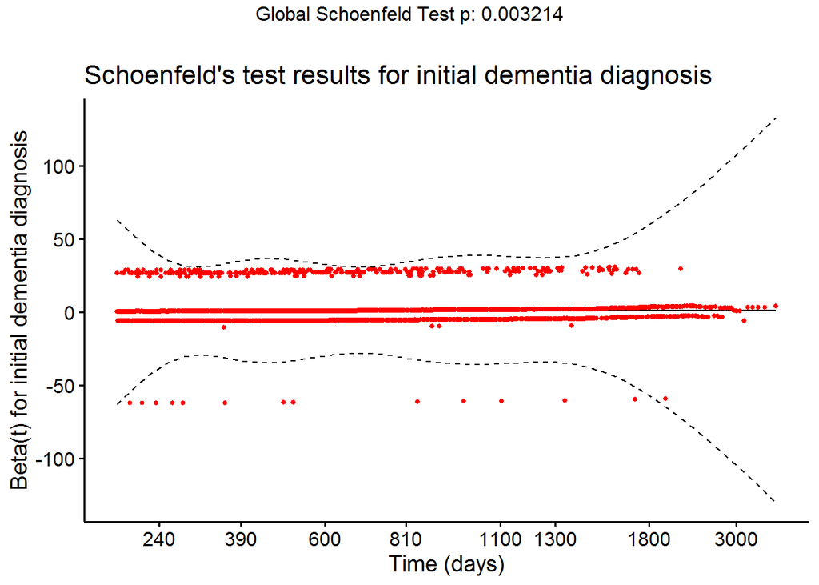

```r
res5 <- cox.zph(cox5)

plot_schoenfeld(res5, "initial dementia diagnosis")
```

```
## [1] "Survival probablity in OxNHS dementia patients: Survivors 180+ days"
## [1] "Adjusted for initial dementia diagnosis (time-dependent analysis)"
```

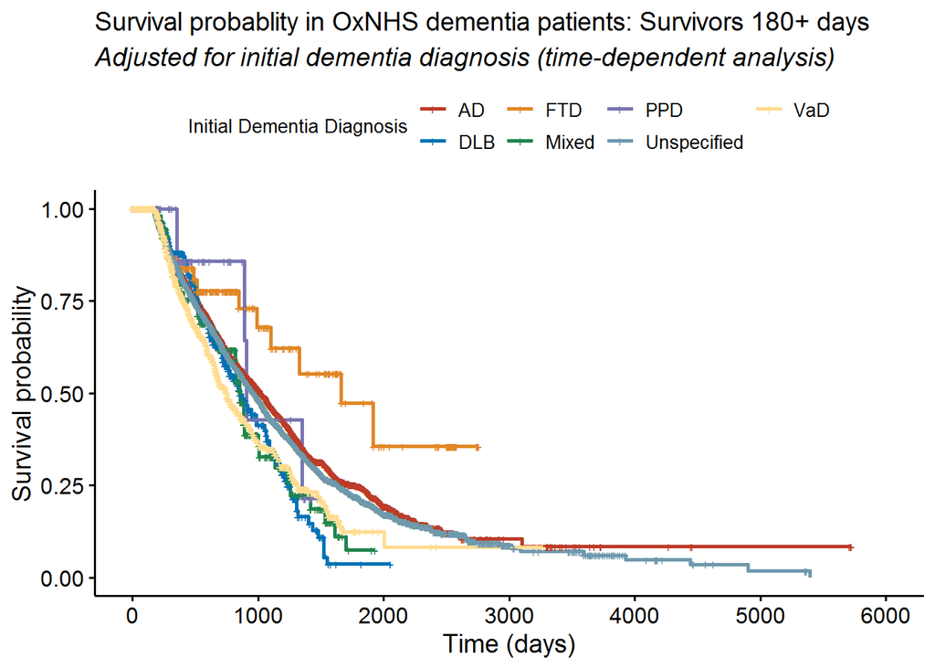

```r
fit5 <- survfit(Surv(time1, time2, event_death) ~ cause_diagper, data = all_df)

plot_surv(fit5, "initial dementia diagnosis", c("AD", "DLB", "FTD", "Mixed", "PPD", "Unspecified", "VaD"))
```

```r
anova(cox5)
```

```
## Analysis of Deviance Table
##  Cox model: response is Surv(time1, time2, event_death)
## Terms added sequentially (first to last)
##
##               loglik  Chisq Df Pr(>|Chi|)
## NULL          -23650
## cause_diagper -23635 31.188  6  2.334e-05 ***
## ---
## Signif. codes:  0 '***' 0.001 '**' 0.01 '*' 0.05 '.' 0.1 ' ' 1
```

**Racial group**

```r
all_df <- all_df %>%
   mutate(Ethnicity_Value = as.factor(Ethnicity_Value)) %>%
   mutate(Ethnicity_Value = relevel(Ethnicity_Value, "White")) #use relevel for ease of interpretation

freq_per_info(all_df$Ethnicity_Value) #reminder of this category's groups
```

```
## var :
##         Frequency   %(NA+)   %(NA-)
## White       36054     75.2     97.1
## NA's        10803     22.5      0.0
## Other         413      0.9      1.1
## Asian         398      0.8      1.1
## Black         284      0.6      0.8
##   Total     47952    100.0    100.0
```

```r
cox6 <- coxph(Surv(time1, time2, event_death) ~ Ethnicity_Value, data = all_df)

summary(cox6)
```

[output not shown]

```r
cox.zph(cox6)
```

```
##                 chisq df     p
## Ethnicity_Value  8.11  3 0.044
## GLOBAL           8.11  3 0.044
```

```
## [1] "Schoenfeld's test results for race"
## [1] "Beta(t) for race"
```

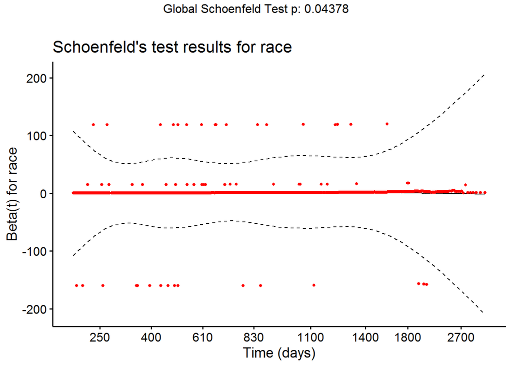

```r
res6 <- cox.zph(cox6)

plot_schoenfeld(res6, "race")
```

```
## [1] "Survival probablity in OxNHS dementia patients: Survivors 180+ days"
## [1] "Adjusted for race (time-dependent analysis)"
```

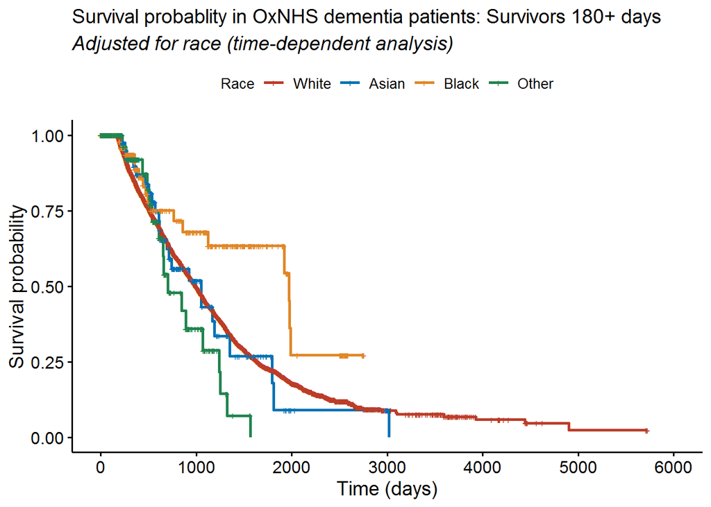

```r
fit6 <- survfit(Surv(time1, time2, event_death) ~ Ethnicity_Value, data = all_df)

plot_surv(fit6, "race", c("White", "Asian", "Black", "Other"))
```

```r
anova(cox6)
```

```
## Analysis of Deviance Table
##  Cox model: response is Surv(time1, time2, event_death)
## Terms added sequentially (first to last)
##
##                 loglik  Chisq Df Pr(>|Chi|)
## NULL            -18164
## Ethnicity_Value -18159 9.6016  3    0.02227 *
## ---
## Signif. codes:  0 '***' 0.001 '**' 0.01 '*' 0.05 '.' 0.1 ' ' 1
```

**Dementia medication class**

```r
table(all_df$type_medclass) #reminder of this category's groups
```

```
##
## Any AChEi Mementine
##     28225      6776
```

```r
cox7 <- coxph(Surv(time1, time2, event_death) ~ type_medclass, data = all_df)

summary(cox7)
```

```
## Call:
## coxph(formula = Surv(time1, time2, event_death) ~ type_medclass,
##     data = all_df)
##
##   n= 35001, number of events= 2092
##    (12951 observations deleted due to missingness)
##
##                           coef exp(coef) se(coef)     z Pr(>|z|)
## type_medclassMementine 0.63488   1.88680  0.05544 11.45   <2e-16 ***
## ---
## Signif. codes:  0 '***' 0.001 '**' 0.01 '*' 0.05 '.' 0.1 ' ' 1
##
##                        exp(coef) exp(-coef) lower .95 upper .95
## type_medclassMementine     1.887       0.53     1.693     2.103
##
## Concordance= 0.539  (se = 0.005 )
## Likelihood ratio test= 115.2  on 1 df,   p=<2e-16
## Wald test            = 131.1  on 1 df,   p=<2e-16
## Score (logrank) test = 135.5  on 1 df,   p=<2e-16
```

```r
cox.zph(cox7)
```

```
##               chisq df   p
## type_medclass 0.694  1 0.4
## GLOBAL        0.694  1 0.4
```

```
## [1] "Schoenfeld's test results for dementia medication class"
## [1] "Beta(t) for dementia medication class"
```

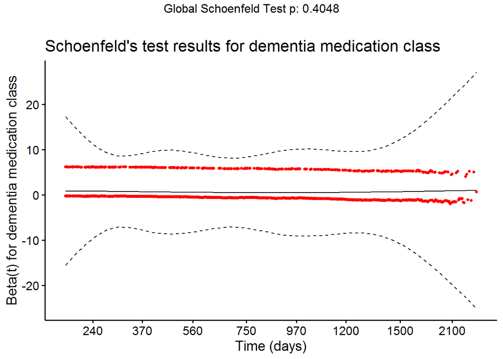

```r
res7 <- cox.zph(cox7)

plot_schoenfeld(res7, "dementia medication class")
```

```
## [1] "Survival probablity in OxNHS dementia patients: Survivors 180+ days"
## [1] "Adjusted for dementia medication class (time-dependent analysis)"
```

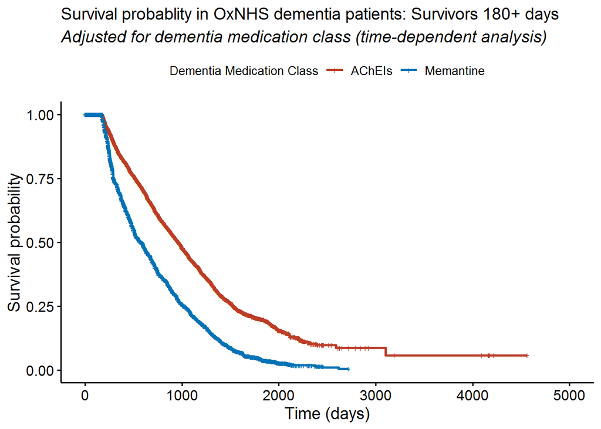

```r
fit7 <- survfit(Surv(time1, time2, event_death) ~ type_medclass, data = all_df)

plot_surv(fit7, "dementia medication class", c("AChEIs", "Memantine"))
```

```r
anova(cox7)
```

```
## Analysis of Deviance Table
##  Cox model: response is Surv(time1, time2, event_death)
## Terms added sequentially (first to last)
##
##               loglik  Chisq Df Pr(>|Chi|)
## NULL          -15086
## type_medclass -15028 115.23  1  < 2.2e-16 ***
## ---
## Signif. codes:  0 '***' 0.001 '**' 0.01 '*' 0.05 '.' 0.1 ' ' 1
```

**Marital status**

```r
freq_per_info(all_df$marital_status)
```

```
## var :
##                    Frequency   %(NA+)   %(NA-)
## Any union              17703     36.9     55.0
## <NA>                   15778     32.9      0.0
## Widowed                10510     21.9     32.7
## Single                  2065      4.3      6.4
## Divorced/Separated      1896      4.0      5.9
##   Total                47952    100.0    100.0
```

```r
cox8 <- coxph(Surv(time1, time2, event_death) ~ marital_status, data = all_df)

summary(cox8)
```

```
## Call:
## coxph(formula = Surv(time1, time2, event_death) ~ marital_status,
##     data = all_df)
##
##   n= 32174, number of events= 2052
##    (15778 observations deleted due to missingness)
##
##                                      coef exp(coef) se(coef)      z Pr(>|z|)
## marital_statusDivorced/Separated -0.36363   0.69515  0.12051 -3.017  0.00255
## marital_statusSingle             -0.01513   0.98498  0.08742 -0.173  0.86258
## marital_statusWidowed             0.28095   1.32438  0.04728  5.942 2.82e-09
##
## marital_statusDivorced/Separated **
## marital_statusSingle
## marital_statusWidowed            ***
## ---
## Signif. codes:  0 '***' 0.001 '**' 0.01 '*' 0.05 '.' 0.1 ' ' 1
##
##                                  exp(coef) exp(-coef) lower .95 upper .95
## marital_statusDivorced/Separated    0.6951     1.4385    0.5489    0.8804
## marital_statusSingle                0.9850     1.0152    0.8299    1.1691
## marital_statusWidowed               1.3244     0.7551    1.2072    1.4530
##
## Concordance= 0.542  (se = 0.007 )
## Likelihood ratio test= 54.98  on 3 df,   p=7e-12
## Wald test            = 53.96  on 3 df,   p=1e-11
## Score (logrank) test = 54.67  on 3 df,   p=8e-12
```

```r
cox.zph(cox8)
```

```
##                chisq df   p
## marital_status  1.85  3 0.6
## GLOBAL          1.85  3 0.6
```

```
## [1] "Schoenfeld's test results for marital status"
## [1] "Beta(t) for marital status"
```

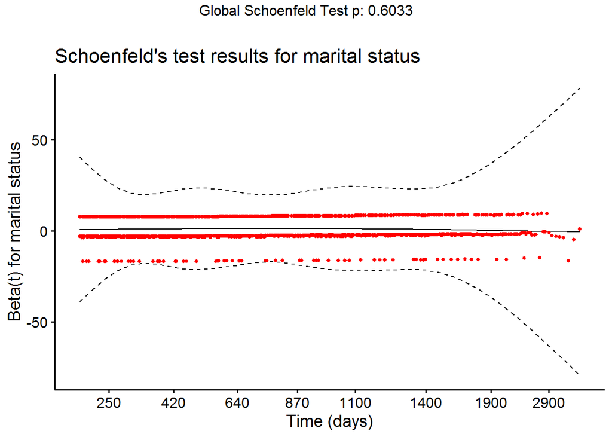

```r
res8 <- cox.zph(cox8)

plot_schoenfeld(res8, "marital status")
```

```
## [1] "Survival probablity in OxNHS dementia patients: Survivors 180+ days"
## [1] "Adjusted for marital status (time-dependent analysis)"
```

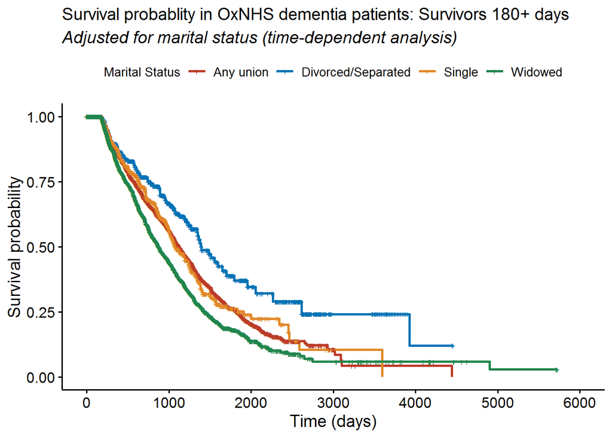

```r
fit8 <- survfit(Surv(time1, time2, event_death) ~ marital_status, data = all_df)

plot_surv(fit8, "marital status", c("Any union", "Divorced/Separated", "Single", "Widowed"))
```

```r
anova(cox8)
```

```
## Analysis of Deviance Table
##  Cox model: response is Surv(time1, time2, event_death)
## Terms added sequentially (first to last)
##
##                loglik  Chisq Df Pr(>|Chi|)
## NULL           -14966
## marital_status -14938 54.984  3  6.919e-12 ***
## ---
## Signif. codes:  0 '***' 0.001 '**' 0.01 '*' 0.05 '.' 0.1 ' ' 1
```

**Type of cognitive assessment**

```r
table(all_df$type_cogeval)
```

```
##
##  MMSE  MOCA
## 11754  6576
```

```r
cox9 <- coxph(Surv(time1, time2, event_death) ~ type_cogeval, data = all_df)

summary(cox9)
```

```
## Call:
## coxph(formula = Surv(time1, time2, event_death) ~ type_cogeval,
##     data = all_df)
##
##   n= 18330, number of events= 1241
##    (29622 observations deleted due to missingness)
##
##                      coef exp(coef) se(coef)      z Pr(>|z|)
## type_cogevalMOCA -0.07363   0.92901  0.06784 -1.085    0.278
##
##                  exp(coef) exp(-coef) lower .95 upper .95
## type_cogevalMOCA     0.929      1.076    0.8134     1.061
##
## Concordance= 0.514  (se = 0.007 )
## Likelihood ratio test= 1.19  on 1 df,   p=0.3
## Wald test            = 1.18  on 1 df,   p=0.3
## Score (logrank) test = 1.18  on 1 df,   p=0.3
```

```r
cox.zph(cox9)
```

```
##              chisq df     p
## type_cogeval  3.42  1 0.064
## GLOBAL        3.42  1 0.064
```

```
## [1] "Schoenfeld's test results for type of cognitive assessment"
## [1] "Beta(t) for type of cognitive assessment"
```

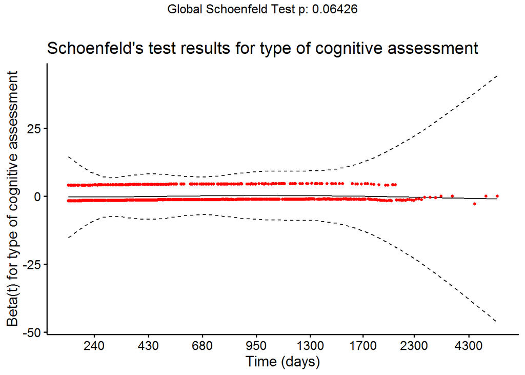

```r
res9 <- cox.zph(cox9)

plot_schoenfeld(res9, "type of cognitive assessment")
```

```
## [1] "Survival probablity in OxNHS dementia patients: Survivors 180+ days"
## [1] "Adjusted for type of cognitive assessment (time-dependent analysis)"
```

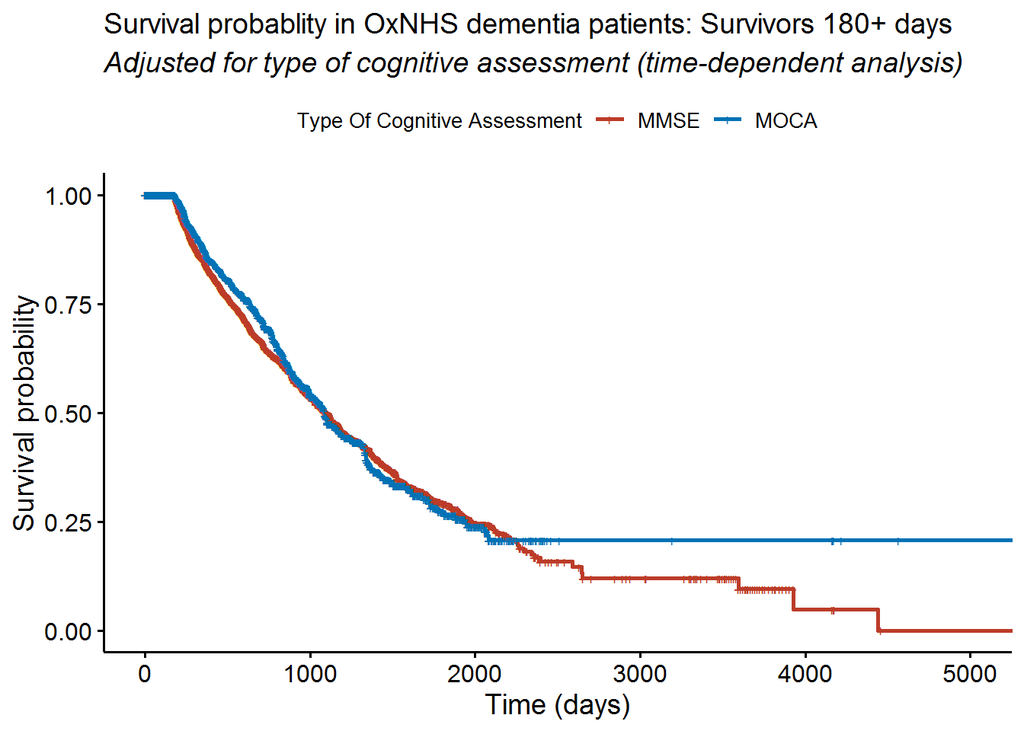

```r
fit9 <- survfit(Surv(time1, time2, event_death) ~ type_cogeval, data = all_df)

plot_surv(fit9, "type of cognitive assessment", c("MMSE", "MOCA"))
```

```r
anova(cox9)
```

```
## Analysis of Deviance Table
##  Cox model: response is Surv(time1, time2, event_death)
## Terms added sequentially (first to last)
##
##               loglik  Chisq Df Pr(>|Chi|)
## NULL         -8750.3
## type_cogeval -8749.7 1.1935  1     0.2746
```

**Score in cognitive assessment**

```r
cox10 <- coxph(Surv(time1, time2, event_death) ~ numerator, data = all_df)

summary(cox10)
```

```
## Call:
## coxph(formula = Surv(time1, time2, event_death) ~ numerator,
##     data = all_df)
##
##   n= 18330, number of events= 1241
##    (29622 observations deleted due to missingness)
##
##                coef exp(coef)  se(coef)      z Pr(>|z|)
## numerator -0.046131  0.954917  0.003803 -12.13   <2e-16 ***
## ---
## Signif. codes:  0 '***' 0.001 '**' 0.01 '*' 0.05 '.' 0.1 ' ' 1
##
##           exp(coef) exp(-coef) lower .95 upper .95
## numerator    0.9549      1.047    0.9478    0.9621
##
## Concordance= 0.598  (se = 0.009 )
## Likelihood ratio test= 137.6  on 1 df,   p=<2e-16
## Wald test            = 147.2  on 1 df,   p=<2e-16
## Score (logrank) test = 149.7  on 1 df,   p=<2e-16
```

```r
cox.zph(cox10)
```

```
##           chisq df    p
## numerator     2  1 0.16
## GLOBAL        2  1 0.16
```

```
## [1] "Schoenfeld's test results for score in cognitive assessment"
## [1] "Beta(t) for score in cognitive assessment"
```

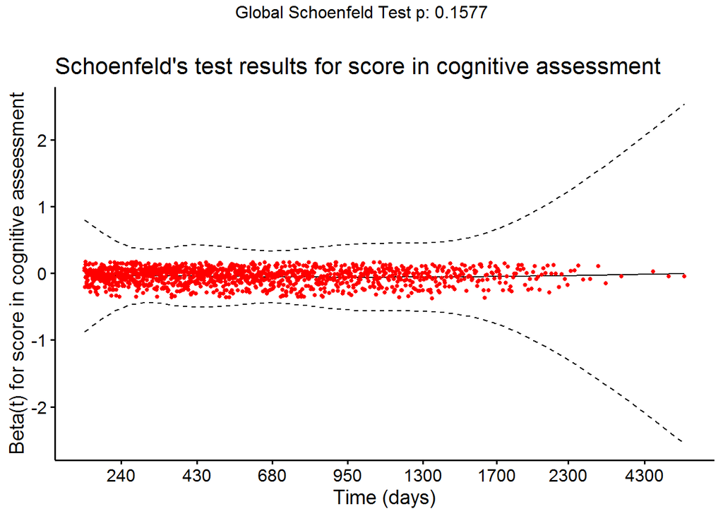

```r
res10 <- cox.zph(cox10)

plot_schoenfeld(res10, "score in cognitive assessment")
```

```r
anova(cox10)
```

```
## Analysis of Deviance Table
##  Cox model: response is Surv(time1, time2, event_death)
## Terms added sequentially (first to last)
##
##            loglik Chisq Df Pr(>|Chi|)
## NULL      -8750.3
## numerator -8681.5 137.6  1  < 2.2e-16 ***
## ---
## Signif. codes:  0 '***' 0.001 '**' 0.01 '*' 0.05 '.' 0.1 ' ' 1
```

**Type of chronic medication**

```r
freq_per_info(all_df$medother_grouped)
```

```
## var :
##                Frequency   %(NA+)   %(NA-)
## <NA>               32315     67.4      0.0
## Antipsychotics      6163     12.9     39.4
## SSRIs               3567      7.4     22.8
## Trazodone           2767      5.8     17.7
## TeCAs               1830      3.8     11.7
## SNRIs                505      1.1      3.2
## Insulin              489      1.0      3.1
## TCAs                 316      0.7      2.0
##   Total            47952    100.0    100.0
```

```r
cox11 <- coxph(Surv(time1, time2, event_death) ~ medother_grouped, data = all_df)

summary(cox11)
```

```
## Call:
## coxph(formula = Surv(time1, time2, event_death) ~ medother_grouped,
##     data = all_df)
##
##   n= 15637, number of events= 855
##    (32315 observations deleted due to missingness)
##
##                               coef exp(coef) se(coef)      z Pr(>|z|)
## medother_groupedInsulin   -0.57832   0.56084  0.22240 -2.600  0.00931 **
## medother_groupedSNRIs     -0.36295   0.69562  0.22744 -1.596  0.11053
## medother_groupedSSRIs     -0.27346   0.76074  0.09156 -2.987  0.00282 **
## medother_groupedTCAs      -0.50886   0.60118  0.22742 -2.238  0.02525 *
## medother_groupedTeCAs     -0.15514   0.85630  0.11376 -1.364  0.17265
## medother_groupedTrazodone  0.26695   1.30598  0.09505  2.808  0.00498 **
## ---
## Signif. codes:  0 '***' 0.001 '**' 0.01 '*' 0.05 '.' 0.1 ' ' 1
##
##                           exp(coef) exp(-coef) lower .95 upper .95
## medother_groupedInsulin      0.5608     1.7830    0.3627    0.8673
## medother_groupedSNRIs        0.6956     1.4376    0.4454    1.0863
## medother_groupedSSRIs        0.7607     1.3145    0.6358    0.9103
## medother_groupedTCAs         0.6012     1.6634    0.3850    0.9388
## medother_groupedTeCAs        0.8563     1.1678    0.6852    1.0702
## medother_groupedTrazodone    1.3060     0.7657    1.0840    1.5734
##
## Concordance= 0.569  (se = 0.011 )
## Likelihood ratio test= 45.09  on 6 df,   p=4e-08
## Wald test            = 45.28  on 6 df,   p=4e-08
## Score (logrank) test = 46.33  on 6 df,   p=3e-08
```

```r
cox.zph(cox11)
```

```
##                  chisq df    p
## medother_grouped  4.24  6 0.64
## GLOBAL            4.24  6 0.64
```

```
## [1] "Schoenfeld's test results for type of chronic medication"
## [1] "Beta(t) for type of chronic medication"
```

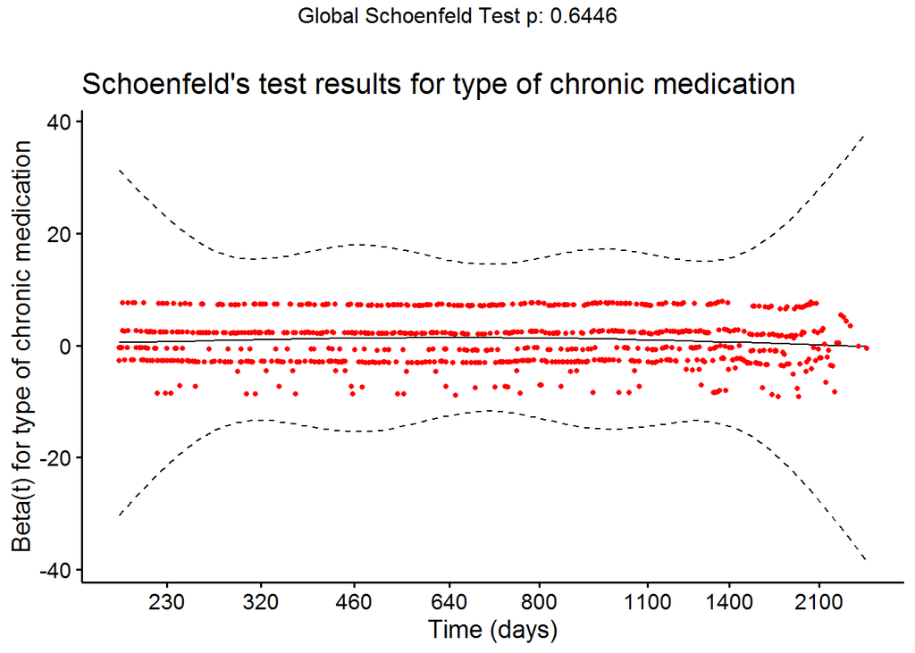

```r
res11 <- cox.zph(cox11)

plot_schoenfeld(res11, "type of chronic medication")
```

```
## [1] "Survival probablity in OxNHS dementia patients: Survivors 180+ days"
## [1] "Adjusted for type of chronic medication (time-dependent analysis)"
```

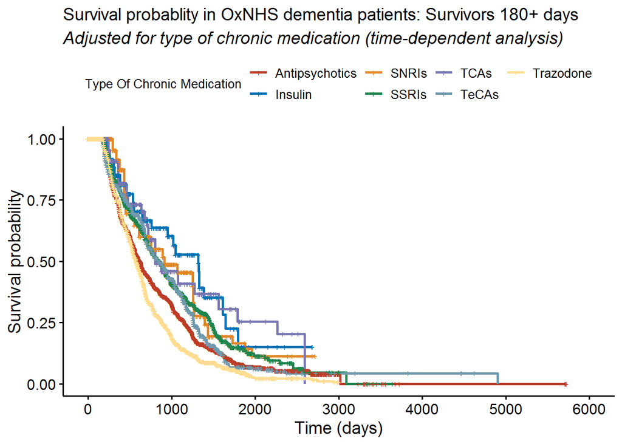

```r
fit11 <- survfit(Surv(time1, time2, event_death) ~ medother_grouped, data = all_df)

plot_surv(fit11, "type of chronic medication", c("Antipsychotics", "Insulin", "SNRIs", "SSRIs",
                                                 "TCAs", "TeCAs", "Trazodone"))
```

```r
anova(cox11)
```

```
## Analysis of Deviance Table
##  Cox model: response is Surv(time1, time2, event_death)
## Terms added sequentially (first to last)
##
##                   loglik  Chisq Df Pr(>|Chi|)
## NULL             -5075.4
## medother_grouped -5052.8 45.091  6   4.49e-08 ***
## ---
## Signif. codes:  0 '***' 0.001 '**' 0.01 '*' 0.05 '.' 0.1 ' ' 1
```

##### **Multivariate models**

**Gender and age of entry**

```r
cox_m0 <- coxph(Surv(time1, time2, event_death) ~ Gender_Value + age_entry, data = all_df) #fit model

summary(cox_m0) #print results
```

```
## Call:
## coxph(formula = Surv(time1, time2, event_death) ~ Gender_Value +
##     age_entry, data = all_df)
##
##   n= 47952, number of events= 3062
##
##                      coef exp(coef) se(coef)      z Pr(>|z|)
## Gender_ValueMale 0.195537  1.215963 0.037234  5.252 1.51e-07 ***
## age_entry        0.070600  1.073152 0.002729 25.874  < 2e-16 ***
## ---
## Signif. codes:  0 '***' 0.001 '**' 0.01 '*' 0.05 '.' 0.1 ' ' 1
##
##                  exp(coef) exp(-coef) lower .95 upper .95
## Gender_ValueMale     1.216     0.8224     1.130     1.308
## age_entry            1.073     0.9318     1.067     1.079
##
## Concordance= 0.64  (se = 0.006 )
## Likelihood ratio test= 738.2  on 2 df,   p=<2e-16
## Wald test            = 670.8  on 2 df,   p=<2e-16
## Score (logrank) test = 679.6  on 2 df,   p=<2e-16
```

```r
cox.zph(cox_m0) #print Schoenfeld's test results
```

```
##                 chisq df     p
## Gender_Value 1.55e-06  1 0.999
## age_entry    4.81e+00  1 0.028
## GLOBAL       4.92e+00  2 0.085
```

```
## $`1`
```

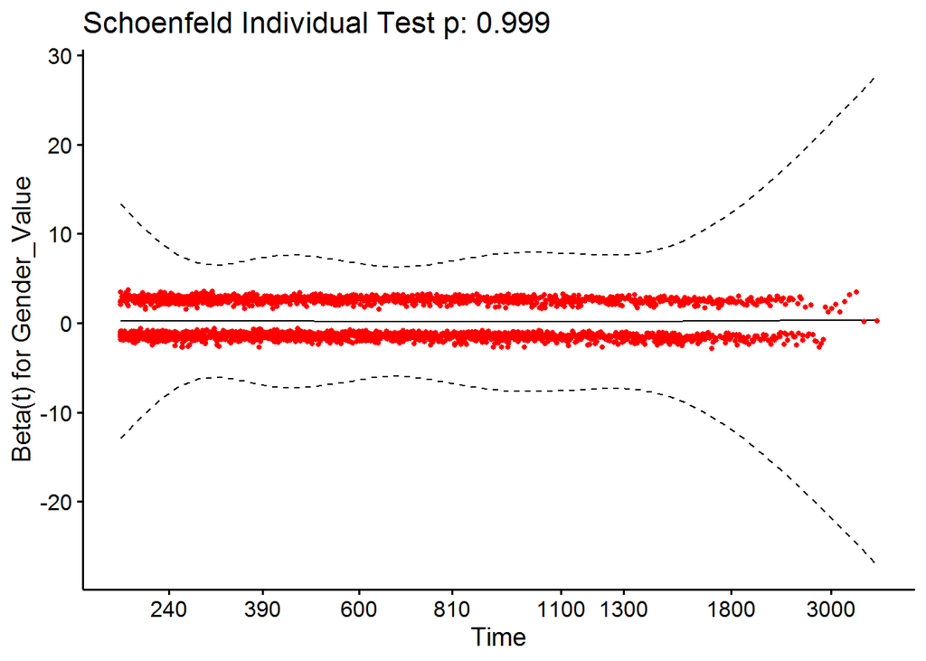

```r
resm0 <- cox.zph(cox_m0) #store Schoenfeld's test results

ggcoxzph(resm0)[1] #plot Schoenfeld's test for first variable (Gender_Value)
```

```
## $`2`
```

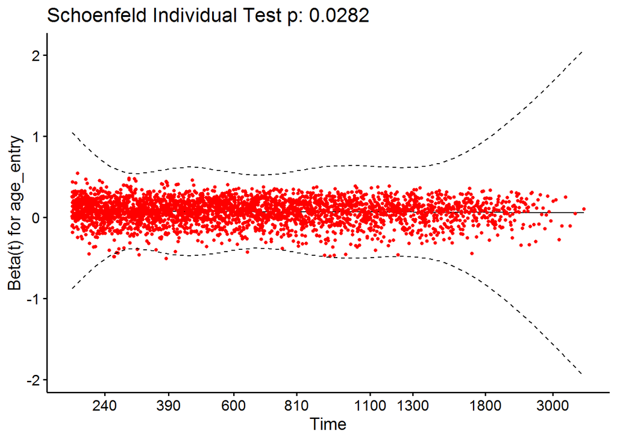

```r
ggcoxzph(resm0)[2] #plot Schoenfeld's test for second variable (age_entry)
```

```r
anova(cox_m0) #ANOVA log likelihood test to determine whether fitted model is significantly better than a no-model solution
```

```
## Analysis of Deviance Table
##  Cox model: response is Surv(time1, time2, event_death)
## Terms added sequentially (first to last)
##
##              loglik    Chisq Df Pr(>|Chi|)
## NULL         -23650
## Gender_Value -23649   2.2456  1      0.134
## age_entry    -23281 735.9123  1     <2e-16 ***
## ---
## Signif. codes:  0 '***' 0.001 '**' 0.01 '*' 0.05 '.' 0.1 ' ' 1
```

Repeat for all other multivaraite models.

**Gender and age of observation**

```r
cox_m1 <- coxph(Surv(time1, time2, event_death) ~ Gender_Value + age_obsv, data = all_df)

summary(cox_m1)
```

```
## Call:
## coxph(formula = Surv(time1, time2, event_death) ~ Gender_Value +
##     age_obsv, data = all_df)
##
##   n= 47952, number of events= 3062
##
##                      coef exp(coef) se(coef)      z Pr(>|z|)
## Gender_ValueMale 0.209855  1.233500 0.037239  5.635 1.75e-08 ***
## age_obsv         0.078955  1.082156 0.002752 28.685  < 2e-16 ***
## ---
## Signif. codes:  0 '***' 0.001 '**' 0.01 '*' 0.05 '.' 0.1 ' ' 1
##
##                  exp(coef) exp(-coef) lower .95 upper .95
## Gender_ValueMale     1.233     0.8107     1.147     1.327
## age_obsv             1.082     0.9241     1.076     1.088
##
## Concordance= 0.651  (se = 0.006 )
## Likelihood ratio test= 921.1  on 2 df,   p=<2e-16
## Wald test            = 824.1  on 2 df,   p=<2e-16
## Score (logrank) test = 835.2  on 2 df,   p=<2e-16
```

```r
cox.zph(cox_m1)
```

```
##               chisq df    p
## Gender_Value 0.0257  1 0.87
## age_obsv     0.2088  1 0.65
## GLOBAL       0.2607  2 0.88
```

```r
resm1 <- cox.zph(cox_m1)

ggcoxzph(resm1)[1]
```

```
## $`1`
```

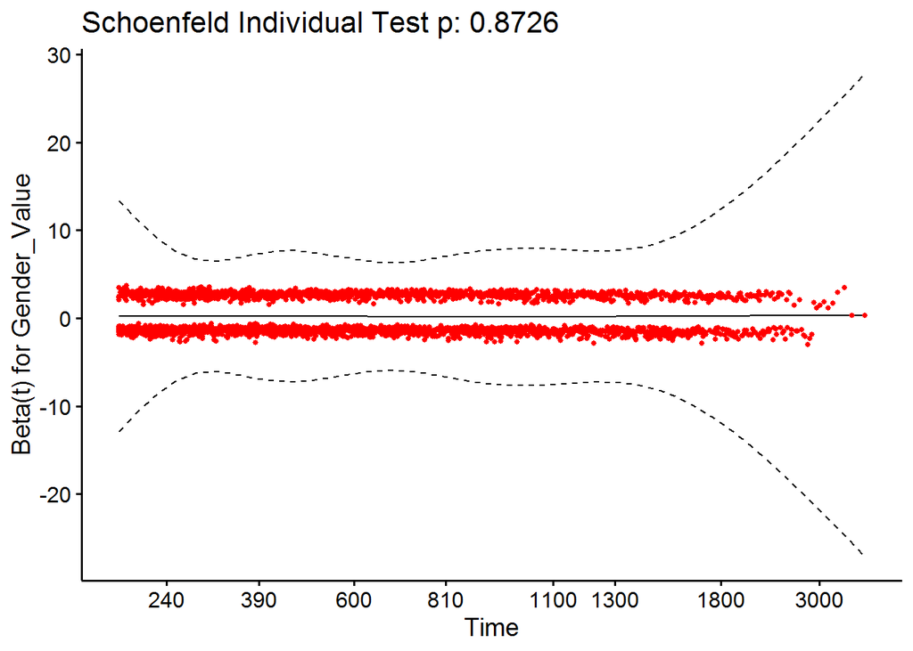

```r
ggcoxzph(resm1)[2]
```

```
## $`2`
```

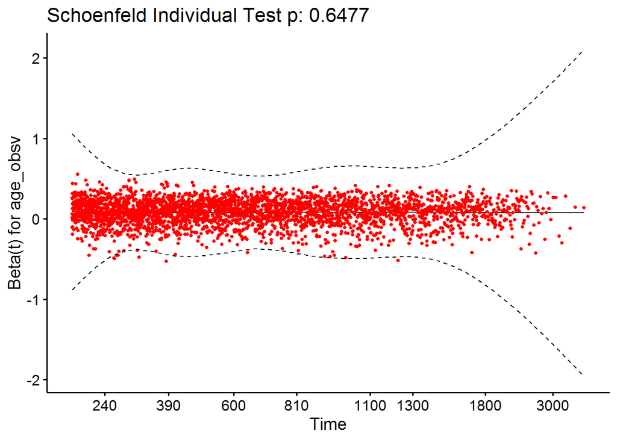

```r
anova(cox_m1)
```

```
## Analysis of Deviance Table
##  Cox model: response is Surv(time1, time2, event_death)
## Terms added sequentially (first to last)
##
##              loglik    Chisq Df Pr(>|Chi|)
## NULL         -23650
## Gender_Value -23649   2.2456  1      0.134
## age_obsv     -23190 918.8934  1     <2e-16 ***
## ---
## Signif. codes:  0 '***' 0.001 '**' 0.01 '*' 0.05 '.' 0.1 ' ' 1
```

We plotted models’ results as forest plots for models that met the proportionality assumption and for which all covariates were significant.

*Forest plot*

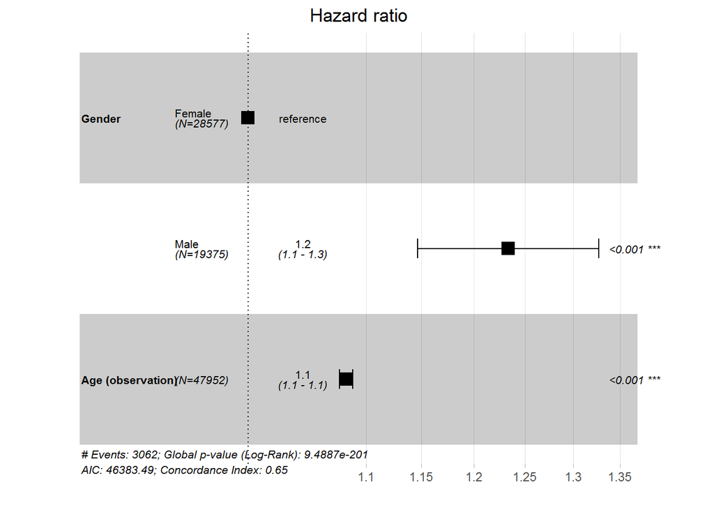

```r
#the steps below apply to all forest plots created henceforward

#subset data for forest plot's aesthetics

forest_df1 <- all_df %>%
  transmute(time1, #extract survival object terms
            time2,
            event_death,
            Gender = factor(Gender_Value), #extract covariates of interest and rename
            `Age (observation)` = age_obsv) %>%
  mutate(Gender = relevel(Gender, ref = "Female")) #relevel when necessary so hazard ratios use consistent reference groups

#fit model again, but use new variable names for aesthetics purposes

new1 <- coxph(Surv(time1, time2, event_death) ~ Gender + `Age (observation)`, data = forest_df1)

#print forest plot

ggforest(new1,
         cpositions = c(0.003, 0.17, 0.4)) #cpositions controls positions of text in plot
```

**Gender and age of diagnosis**

```r
cox_m2 <- coxph(Surv(time1, time2, event_death) ~ Gender_Value + age_diag, data = all_df)

summary(cox_m2)
```

```
## Call:
## coxph(formula = Surv(time1, time2, event_death) ~ Gender_Value +
##     age_diag, data = all_df)
##
##   n= 47952, number of events= 3062
##
##                      coef exp(coef) se(coef)      z Pr(>|z|)
## Gender_ValueMale 0.195375  1.215767 0.037273  5.242 1.59e-07 ***
## age_diag         0.064826  1.066974 0.002637 24.582  < 2e-16 ***
## ---
## Signif. codes:  0 '***' 0.001 '**' 0.01 '*' 0.05 '.' 0.1 ' ' 1
##
##                  exp(coef) exp(-coef) lower .95 upper .95
## Gender_ValueMale     1.216     0.8225     1.130     1.308
## age_diag             1.067     0.9372     1.061     1.073
##
## Concordance= 0.634  (se = 0.006 )
## Likelihood ratio test= 659.9  on 2 df,   p=<2e-16
## Wald test            = 605.6  on 2 df,   p=<2e-16
## Score (logrank) test = 612.6  on 2 df,   p=<2e-16
```

```r
cox.zph(cox_m2)
```

```
##               chisq df     p
## Gender_Value 0.0937  1 0.760
## age_diag     6.6085  1 0.010
## GLOBAL       6.6250  2 0.036
```

```r
resm2 <- cox.zph(cox_m2)

ggcoxzph(resm2)[1]
```

```
## $`1`
```

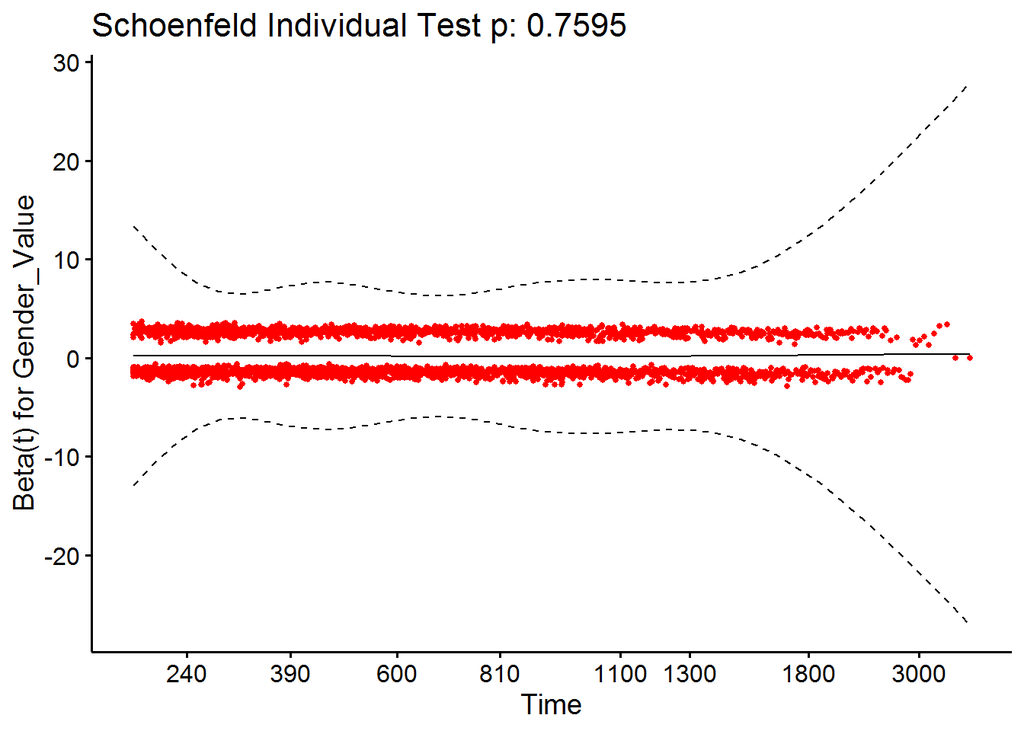

```r
ggcoxzph(resm2)[2]
```

```
## $`2`
```

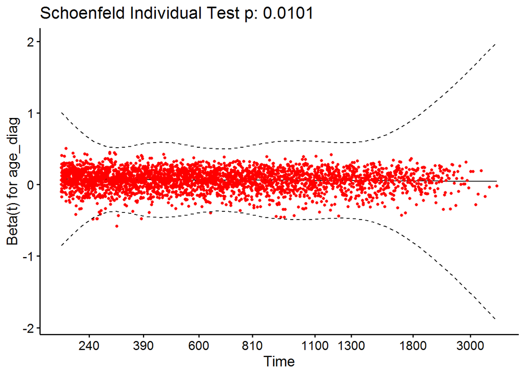

```r
anova(cox_m2)
```

```
## Analysis of Deviance Table
##  Cox model: response is Surv(time1, time2, event_death)
## Terms added sequentially (first to last)
##
##              loglik    Chisq Df Pr(>|Chi|)
## NULL         -23650
## Gender_Value -23649   2.2456  1      0.134
## age_diag     -23320 657.6857  1     <2e-16 ***
## ---
## Signif. codes:  0 '***' 0.001 '**' 0.01 '*' 0.05 '.' 0.1 ' ' 1
```

**Gender and dementia medication exposure**

```r
cox_m3 <- coxph(Surv(time1, time2, event_death) ~ Gender_Value + med_exposure, data = all_df)

summary(cox_m3)
```

```
## Call:
## coxph(formula = Surv(time1, time2, event_death) ~ Gender_Value +
##     med_exposure, data = all_df)
##
##   n= 47952, number of events= 3062
##
##                           coef exp(coef) se(coef)      z Pr(>|z|)
## Gender_ValueMale       0.05263   1.05404  0.03675  1.432    0.152
## med_exposureunexposed -0.26020   0.77090  0.04074 -6.387 1.69e-10 ***
## ---
## Signif. codes:  0 '***' 0.001 '**' 0.01 '*' 0.05 '.' 0.1 ' ' 1
##
##                       exp(coef) exp(-coef) lower .95 upper .95
## Gender_ValueMale         1.0540     0.9487    0.9808     1.133
## med_exposureunexposed    0.7709     1.2972    0.7117     0.835
##
## Concordance= 0.518  (se = 0.006 )
## Likelihood ratio test= 44.58  on 2 df,   p=2e-10
## Wald test            = 43.03  on 2 df,   p=5e-10
## Score (logrank) test = 43.26  on 2 df,   p=4e-10
```

```r
cox.zph(cox_m3)
```

```
##                chisq df       p
## Gender_Value  0.0394  1    0.84
## med_exposure 29.8909  1 4.6e-08
## GLOBAL       29.9314  2 3.2e-07
```

```r
resm3 <- cox.zph(cox_m3)

ggcoxzph(resm3)[1]
```

```
## $`1`
```

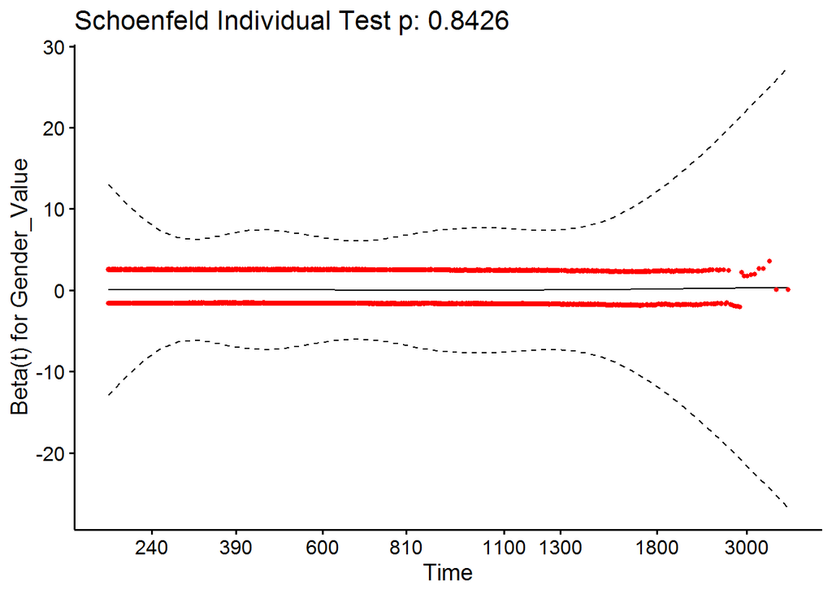

```r
ggcoxzph(resm3)[2]
```

```
## $`2`
```

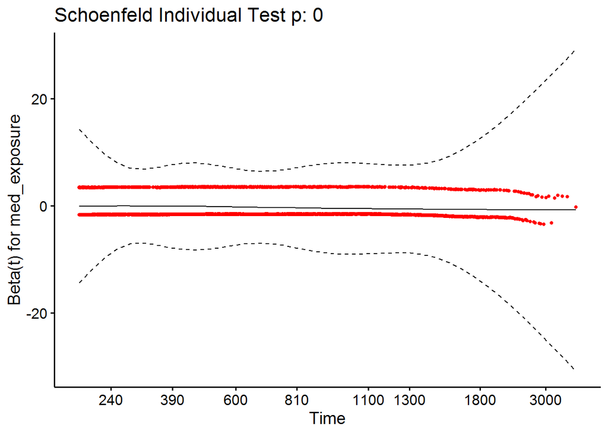

```r
anova(cox_m3)
```

```
## Analysis of Deviance Table
##  Cox model: response is Surv(time1, time2, event_death)
## Terms added sequentially (first to last)
##
##              loglik   Chisq Df Pr(>|Chi|)
## NULL         -23650
## Gender_Value -23649  2.2456  1      0.134
## med_exposure -23628 42.3366  1  7.684e-11 ***
## ---
## Signif. codes:  0 '***' 0.001 '**' 0.01 '*' 0.05 '.' 0.1 ' ' 1
```

**Gender and initial diagnosis**

```r
cox_m4 <- coxph(Surv(time1, time2, event_death) ~ Gender_Value + cause_diagper, data = all_df)

summary(cox_m4)
```

```
## Call:
## coxph(formula = Surv(time1, time2, event_death) ~ Gender_Value +
##     cause_diagper, data = all_df)
##
##   n= 47952, number of events= 3062
##
##                              coef exp(coef) se(coef)      z Pr(>|z|)
## Gender_ValueMale          0.04868   1.04989  0.03682  1.322  0.18613
## cause_diagperDLB          0.34945   1.41829  0.11821  2.956  0.00312 **
## cause_diagperFTD         -0.57912   0.56039  0.26905 -2.152  0.03136 *
## cause_diagperMixedADVaD   0.30349   1.35457  0.16958  1.790  0.07351 .
## cause_diagperPPD         -0.03153   0.96896  0.50110 -0.063  0.94983
## cause_diagperUnspecified  0.06539   1.06758  0.03909  1.673  0.09434 .
## cause_diagperVaD          0.33352   1.39587  0.08206  4.064 4.82e-05 ***
## ---
## Signif. codes:  0 '***' 0.001 '**' 0.01 '*' 0.05 '.' 0.1 ' ' 1
##
##                          exp(coef) exp(-coef) lower .95 upper .95
## Gender_ValueMale            1.0499     0.9525    0.9768    1.1285
## cause_diagperDLB            1.4183     0.7051    1.1250    1.7881
## cause_diagperFTD            0.5604     1.7845    0.3307    0.9495
## cause_diagperMixedADVaD     1.3546     0.7382    0.9715    1.8886
## cause_diagperPPD            0.9690     1.0320    0.3629    2.5873
## cause_diagperUnspecified    1.0676     0.9367    0.9888    1.1526
## cause_diagperVaD            1.3959     0.7164    1.1885    1.6395
##
## Concordance= 0.518  (se = 0.006 )
## Likelihood ratio test= 32.93  on 7 df,   p=3e-05
## Wald test            = 33.24  on 7 df,   p=2e-05
## Score (logrank) test = 33.65  on 7 df,   p=2e-05
```

```r
cox.zph(cox_m4)
```

```
##                 chisq df      p
## Gender_Value   0.0651  1 0.7986
## cause_diagper 19.6966  6 0.0031
## GLOBAL        19.7178  7 0.0062
```

```r
resm4 <- cox.zph(cox_m4)

ggcoxzph(resm4)[1]
```

```
## $`1`
```

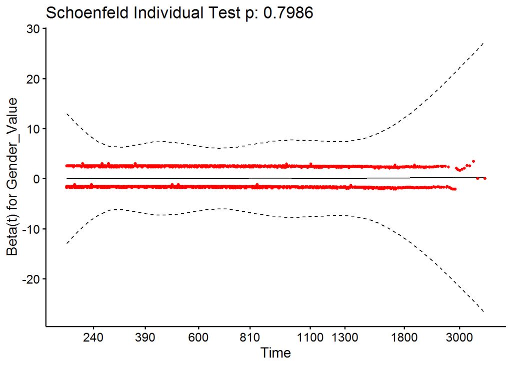

```r
ggcoxzph(resm4)[2]
```

```
## $`2`
```

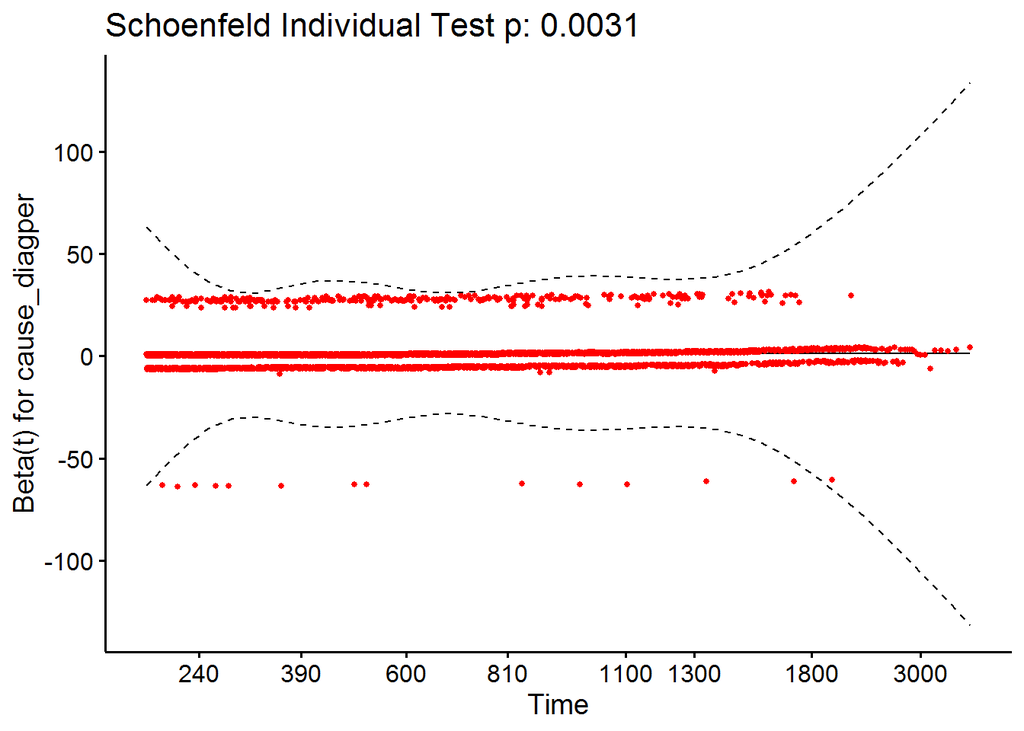

```r
anova(cox_m4)
```

```
## Analysis of Deviance Table
##  Cox model: response is Surv(time1, time2, event_death)
## Terms added sequentially (first to last)
##
##               loglik   Chisq Df Pr(>|Chi|)
## NULL          -23650
## Gender_Value  -23649  2.2456  1      0.134
## cause_diagper -23634 30.6853  6  2.911e-05 ***
## ---
## Signif. codes:  0 '***' 0.001 '**' 0.01 '*' 0.05 '.' 0.1 ' ' 1
```

**Gender, age at observation, and age of entry**

```r
cox_m5 <- coxph(Surv(time1, time2, event_death) ~ Gender_Value + age_obsv + age_entry, data = all_df)

summary(cox_m5)
```

```
## Call:
## coxph(formula = Surv(time1, time2, event_death) ~ Gender_Value +
##     age_obsv + age_entry, data = all_df)
##
##   n= 47952, number of events= 3062
##
##                      coef exp(coef) se(coef)       z Pr(>|z|)
## Gender_ValueMale  0.17016   1.18549  0.03727   4.566 4.97e-06 ***
## age_obsv          0.89788   2.45440  0.03545  25.325  < 2e-16 ***
## age_entry        -0.82767   0.43707  0.03553 -23.292  < 2e-16 ***
## ---
## Signif. codes:  0 '***' 0.001 '**' 0.01 '*' 0.05 '.' 0.1 ' ' 1
##
##                  exp(coef) exp(-coef) lower .95 upper .95
## Gender_ValueMale    1.1855     0.8435    1.1020    1.2753
## age_obsv            2.4544     0.4074    2.2896    2.6310
## age_entry           0.4371     2.2880    0.4077    0.4686
##
## Concordance= 0.704  (se = 0.006 )
## Likelihood ratio test= 1697  on 3 df,   p=<2e-16
## Wald test            = 1272  on 3 df,   p=<2e-16
## Score (logrank) test = 1342  on 3 df,   p=<2e-16
```

```r
cox.zph(cox_m5)
```

```
##                chisq df      p
## Gender_Value   0.548  1 0.4590
## age_obsv      10.004  1 0.0016
## age_entry      4.768  1 0.0290
## GLOBAL       208.033  3 <2e-16
```

```r
resm5 <- cox.zph(cox_m5)

ggcoxzph(resm5)[1]
```

```
## $`1`
```

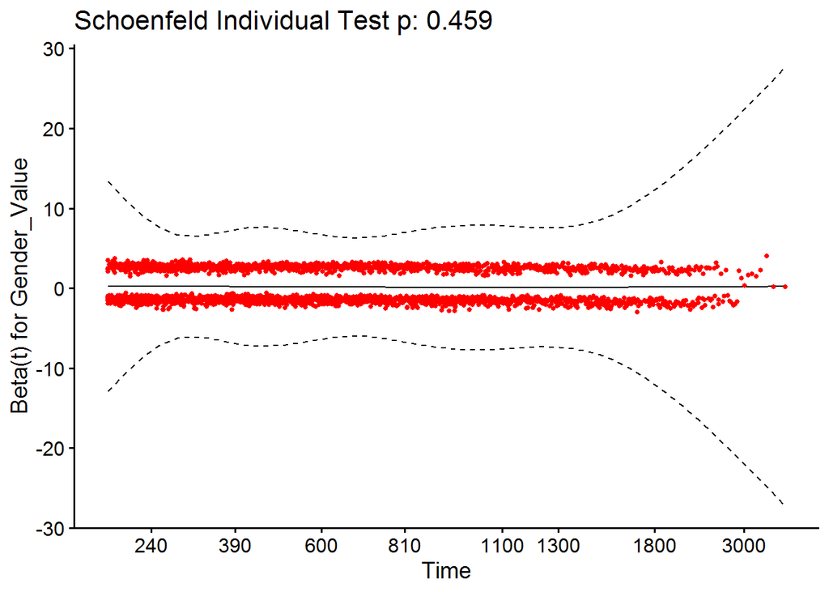